# Risk Analysis of Australia’s Higher Education Loan Program (HELP)

Alana Dabelstein, Anh-Thu Hoang, Chenxi Zhang

01/06/2023

# 1 Introduction

Educational attainment is associated with higher labour force participation, higher income, greater wealth, lower financial stress and healthier behaviours (OECD, 2018). Despite this, many individuals have debt-averse attitudes which deter them from applying to university (Callender & Mason, 2017).

Tertiary education cost has grown fast over time while there has been flat growth in the wages of young adults aged 25–34 (Preston, 2023). The Higher Education Loan Program (HELP) is an income-contingent loan provided by the Australian Government to eligible students to cover this cost.

The income-contingency reduces the risk of borrowing for students where the future value of education or training is uncertain, especially for students from low-income backgrounds (Albrecht & Ziderman, 1991) as repayment is only required once their income reaches the minimum threshold through the income tax system. Enrolments and the number of people with outstanding HELP debts has steadily increased (Universities Australia, 2022).

As of 2021-22, the minimum repayment threshold is $47,014. It is projected that HELP debt will total almost $200 billion in 2024–25 and almost one-third will be written off. (Jackson et al., 2016). For debtors who do not earn the minimum threshold, the risk of loan defaults increase and the burden of repayment falls on taxpayers and more successful borrowers (Baum, 2016).

Using data retrieved from Australian Taxation Office (2022), this report will attempt to analyse the risks of HELP on its long-term sustainability through the variables of time, age, sex, income, and recoverability. Analysis of distribution of income and changes to the median and mean earnings of debtors will be able to inform the expectations of loan recoverability, which is also supported through an examination of annual repayments and new loans issued under the program, as well as comparison of debt writeoff with commercial banks.

# 2 Analysis

## 2.1 Outstanding Debt and Debtors by Year, Age and Sex

This section will investigate:

1. *How does total outstanding debt and number of debtors change from the financial years 2005-06 to 2021-22?*
2. *How does total outstanding debt and number of debtors change over time by i) sex and ii) age group?*

### 2.1.1 Total Outstanding Debt and Total Debtors 2005-2022

Table 2.1: Total Debtors (in millions) and Total Oustanding Debt (in billions)

| Year | Total Number of Debtors (millions) | Total Outstanding Debt (billions $) |
| --- | --- | --- |
| 2005 | 1.18 | 12.39 |
| 2006 | 1.25 | 14.00 |
| 2007 | 1.31 | 15.81 |
| 2008 | 1.37 | 17.82 |
| 2009 | 1.46 | 19.91 |
| 2010 | 1.57 | 22.57 |
| 2011 | 1.68 | 25.53 |
| 2012 | 1.82 | 28.99 |
| 2013 | 2.00 | 33.82 |
| 2014 | 2.22 | 40.18 |
| 2015 | 2.47 | 47.89 |
| 2016 | 2.66 | 53.99 |
| 2017 | 2.87 | 61.92 |
| 2018 | 2.97 | 66.65 |
| 2019 | 2.85 | 66.39 |
| 2020 | 2.90 | 68.72 |
| 2021 | 3.00 | 74.39 |

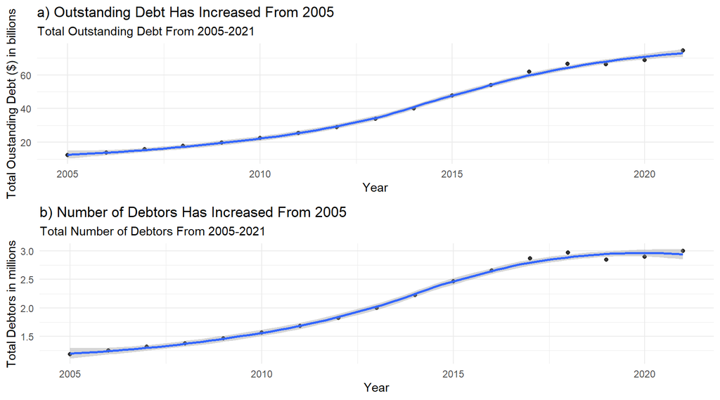

Figure 2.1: Total outstanding debt and number of debtors from the financial years 2005-06 to 2021-22

Table 2.1and Figure 2.1 shows the total number of debtors increased from 1.18 million in 2005 to 3 million in 2021. The outstanding debt total was $12.39 billion in 2005 which rose to $74.39 billion in 2021. A rapid increase can be seen from 2010 to 2015, where total outstanding debt rose by $25.32 billion. Interestingly, a small decrease in debtors can be observed from 2018 to 2019 which may be a factor for the plateau in outstanding debt from years 2018-2020.

### 2.1.2 Average Debtors and Oustanding Debt by Sex

Table 2.2: Average Debtors and Outstanding Debt By Sex from 2005-2021

| Sex | Mean Number of Debtors | Mean Outstanding Debt (in billions) |
| --- | --- | --- |
| Female | 158046.2 | 2.84 |
| Male | 103717.2 | 2.09 |

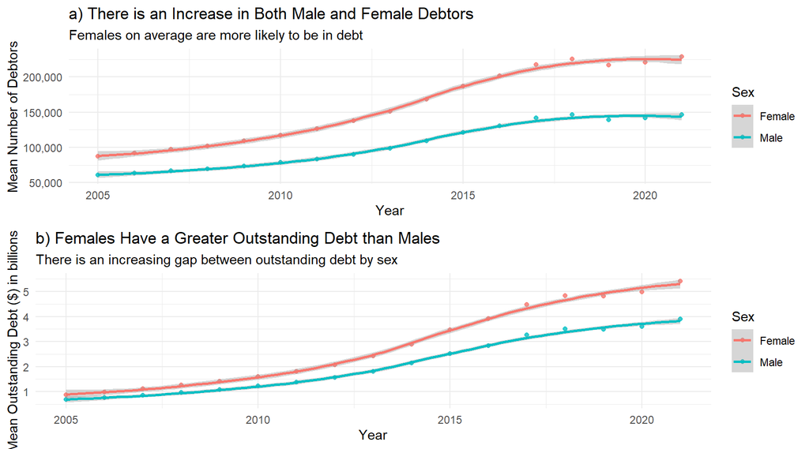

Figure 2.2: Total outstanding debt and number of debtors by sex from the financial years 2005-06 to 2021-22

Table and 2.2 and Figure 2.2 groups mean debtors and outstanding debt by sex, revealing that there are significantly more female debtors than males. The reason is likely an increase in university enrolments, with female enrollments growing faster than male enrollments (Preston, 2023). From 2005-2021, on average, 158, 046.2 females are in debt, compared to 103,717.2 males. This difference in average of 54,329 female debtors could factor for the $750 million difference in average outstanding debt. An increasing gap can be observed between the number of debtors and outstanding debt between females and males.

### 2.1.3 Average Debtors and Oustanding Debt by Age Group

Table 2.3: Average Number of Debtors and Outstanding Debt by Age Group from 2005-2021

| Age_Range | Mean Number of Debtors (in thousands) | Mean Oustanding Debt (in millions) |
| --- | --- | --- |
| 0-19 | 51.56 | 427.59 |
| 20-29 | 524.87 | 11589.59 |
| 30-39 | 266.54 | 4992.88 |
| 40-49 | 121.98 | 1713.30 |
| 50-59 | 53.60 | 681.63 |
| 60-69 | 20.46 | 247.91 |
| 70+ | 7.64 | 79.40 |
| Unknown | 0.40 | 1.81 |

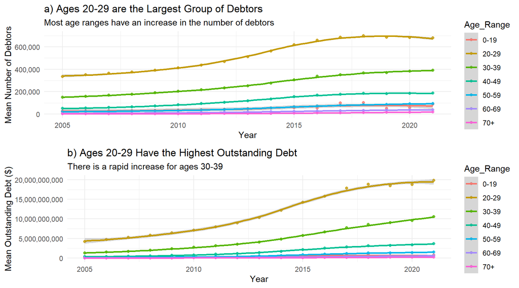

Figure 2.3: Total outstanding debt and number of debtors by age from the financial years 2005-06 to 2021-22

Table 2.3 and figure 2.3 show the age group with the greatest number of debtors is 20-29. Excluding the group for unknown age, 70+ has the lowest number of debtors. The same pattern can be observed for mean outstanding debt. Younger age groups have a higher risk of debt than older age groups with the exception of 0-19. An increase in the number of debtors and outstanding debt can be seen for all age groups. From 2018-2021, there is a sudden drop in number of debtors for 0–19-year-olds, which also results in a drop in outstanding debt.

## 2.2 Income and Outstanding Debt

This section investigates:

1. *What was the distribution of taxable (HELP repayment) income of HELP debtors in Australian States and Territories in the 2021-22 financial year?*
2. *What trend can be observed of the median and mean taxable (HELP repayment) income of HELP debtors in Australia over time?*

### 2.2.1 Income Distribution

Table 2.4: Table of count of outstanding HELP debtors in each income group by State or Territory in 2021-22

| Financial Year | HELP Repayment Income | ACT | NSW | NT | QLD | SA | TAS | VIC | WA |
| --- | --- | --- | --- | --- | --- | --- | --- | --- | --- |
| 2021–22 | Up to $9,999 | 3243 | 46381 | 718 | 32332 | 10248 | 3017 | 40602 | 15759 |
| 2021–22 | $10,000 to $19,999 | 3627 | 56153 | 890 | 39486 | 13631 | 3600 | 49094 | 18913 |
| 2021–22 | $20,000 to $29,999 | 5553 | 97841 | 1633 | 74315 | 24761 | 6491 | 93273 | 33125 |
| 2021–22 | $30,000 to $39,999 | 5443 | 91484 | 1537 | 69598 | 22852 | 5950 | 89210 | 29094 |
| 2021–22 | $40,000 to $49,999 | 4972 | 85121 | 1657 | 68943 | 21792 | 5554 | 82509 | 26559 |
| 2021–22 | $50,000 to $59,999 | 4488 | 72797 | 1510 | 55047 | 17316 | 4316 | 66696 | 20456 |
| 2021–22 | $60,000 to $69,999 | 4544 | 57955 | 1376 | 39743 | 13599 | 3396 | 52250 | 16023 |
| 2021–22 | $70,000 to $79,999 | 5003 | 48373 | 1361 | 32054 | 11030 | 2923 | 48095 | 13175 |
| 2021–22 | $80,000 to $89,999 | 4100 | 38831 | 1215 | 25120 | 8332 | 2184 | 34171 | 10746 |
| 2021–22 | $90,000 to $99,999 | 2716 | 25464 | 870 | 15127 | 4975 | 1322 | 20751 | 7040 |
| 2021–22 | $100,000 to $109,999 | 1750 | 15675 | 607 | 9431 | 2721 | 785 | 13090 | 4346 |
| 2021–22 | $110,000 to $119,999 | 1138 | 10105 | 451 | 5987 | 1699 | 443 | 8496 | 3006 |
| 2021–22 | $120,000 to $129,999 | 660 | 6367 | 270 | 3856 | 1068 | 264 | 5218 | 1939 |
| 2021–22 | $130,000 or more | 1283 | 14199 | 619 | 8617 | 2262 | 541 | 11815 | 5054 |

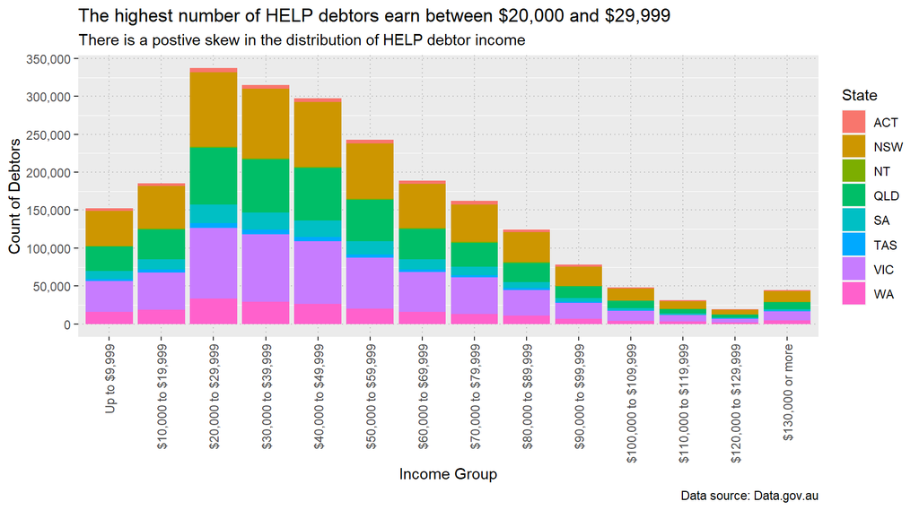

Figure 2.4: Distribution of HELP debtor income in Australian States and Territories

Table 2.4 presents the counts of students with outstanding HELP debt in each income group, incremented by $10,000, in all States and Territories in the 2021-22 fiscal year. The distribution of debtors is depicted in Figure 2.4. Across all income groups, NSW, QLD, and VIC have the highest number of debtors. There are 336,992 outstanding HELP debtors earning between $20,000 and $29,999, the highest of all income groups. The number of debtors diminishes gradually as the income group increases. The income group with the lowest number of outstanding debtors is $120,000 to $129,999, with 19,642 debtors. It is to be noted that the “$130,000 or more” income group is an exception as it does not observe the $10,000 increment rule.

### 2.2.2 Median and Mean Income

Table 2.5: Table of the median and mean taxable income group of outstanding HELP debtors in Australia from 2009-10 to 2021-22

| Financial Year | Count of Outstanding Debtors | Median Income | Mean Income |
| --- | --- | --- | --- |
| 2009–10 | 1077050 | $30,000 to $39,999 | $40,000 to $49,999 |
| 2010–11 | 1094860 | $20,000 to $29,999 | $30,000 to $39,999 |
| 2011–12 | 1175518 | $20,000 to $29,999 | $30,000 to $39,999 |
| 2012–13 | 1295840 | $20,000 to $29,999 | $30,000 to $39,999 |
| 2013–14 | 1342673 | $30,000 to $39,999 | $40,000 to $49,999 |
| 2014–15 | 1490369 | $30,000 to $39,999 | $40,000 to $49,999 |
| 2015–16 | 1583158 | $20,000 to $29,999 | $30,000 to $39,999 |
| 2016–17 | 1817153 | $30,000 to $39,999 | $40,000 to $49,999 |
| 2017–18 | 1953000 | $30,000 to $39,999 | $40,000 to $49,999 |
| 2018–19 | 2098614 | $30,000 to $39,999 | $40,000 to $49,999 |
| 2019–20 | 2102810 | $30,000 to $39,999 | $40,000 to $49,999 |
| 2020–21 | 2152356 | $40,000 to $49,999 | $50,000 to $59,999 |
| 2021–22 | 2227213 | $40,000 to $49,999 | $50,000 to $59,999 |

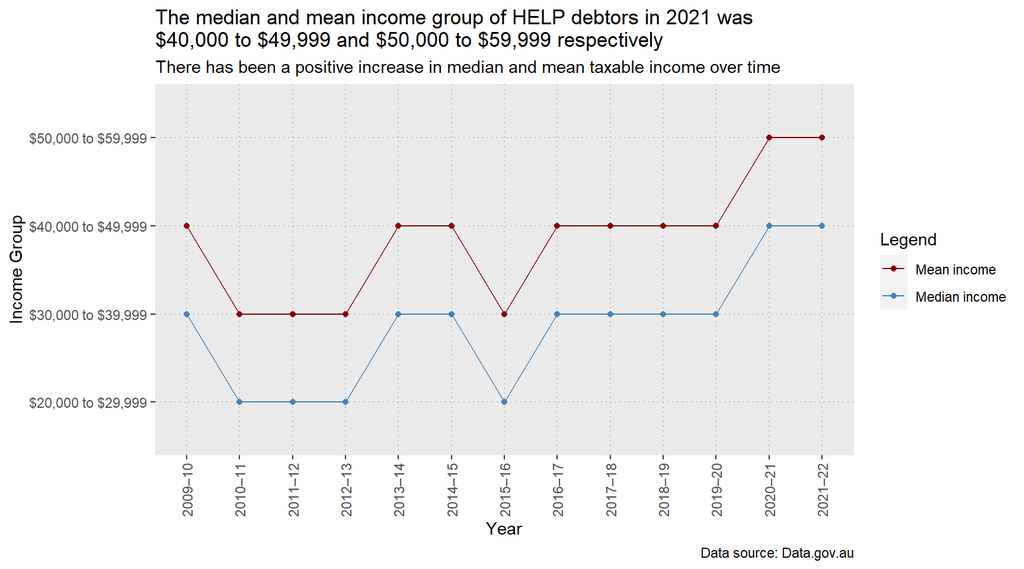

Figure 2.5: Median and mean income of HELP debtors in Australia from 2009 to 2021

Table 2.5 presents the median and mean (average) income of HELP debtors in Australia from 2009 to 2021 and the trends are illustrated in Figure 2.5. The median and average income follow the same positive trend, increasing overall by one income group ($10,000) since 2009. The median typically sits below the average by one income group. In 2009, the median income group was $30,000 to $39,999 and the mean income group was $40,000 to $49,999. By 2021, the median had increased to $40,000 to $49,999 and the average to $50,000 to $59,999. The lowest median and mean income group of HELP debtors were observed in the 2010-11 to 2012-13 and 2015-16 fiscal years, at $20,000 to $29,999 and $30,000 to $39,999 respectively.

## 2.3 Recoverability of HELP Debt Over Time

This section investigates:

1. *How has recoverability (annual debt incurred vs repayment) of HELP debt changed over the period FY07 to FY22*
2. *Has there been a growth in HELP debt write-offs and how does this compare with the banking industry*

In order to investigate whether the Australian Government is able to recover debt issued under the HELP program, cumulative data available from FY07 to FY22 have been translated to annual increase for new debt incurred (including indexation) and repayments received (including compulsory repayments, voluntary repayments and bonus on voluntary repayments which ceased in FY17).

### 2.3.1 Annual Debt Incurred vs Repayments

Table 2.6: Annual New Debt Incurred and Repayments

| Financial Year | Annual Incurred (incl. Indexation) | Annual Repayment | Annual Repayment Ratio |
| --- | --- | --- | --- |
| 2007 | 2581178570 | 975913382 | 0.3780883 |
| 2008 | 2923882857 | 1125174935 | 0.3848222 |
| 2009 | 3386256294 | 1376349290 | 0.4064516 |
| 2010 | 3380714899 | 1360909343 | 0.4025508 |
| 2011 | 4170916618 | 1504227434 | 0.3606467 |
| 2012 | 4679045735 | 1718710202 | 0.3673207 |
| 2013 | 5226014705 | 1740953530 | 0.3331322 |
| 2014 | 6680830864 | 1826108374 | 0.2733355 |
| 2015 | 8310345095 | 1903945888 | 0.2291055 |
| 2016 | 9881383040 | 2122435307 | 0.2147913 |
| 2017 | 8553217833 | 2393654452 | 0.2798543 |
| 2018 | 10711864600 | 2692609208 | 0.2513670 |
| 2019 | 7953021645 | 3189578901 | 0.4010525 |
| 2020 | 3523260836 | 3788890135 | 1.0753930 |
| 2021 | 6563827461 | 4258662938 | 0.6488079 |
| 2022 | 10693276354 | 5006631043 | 0.4682037 |

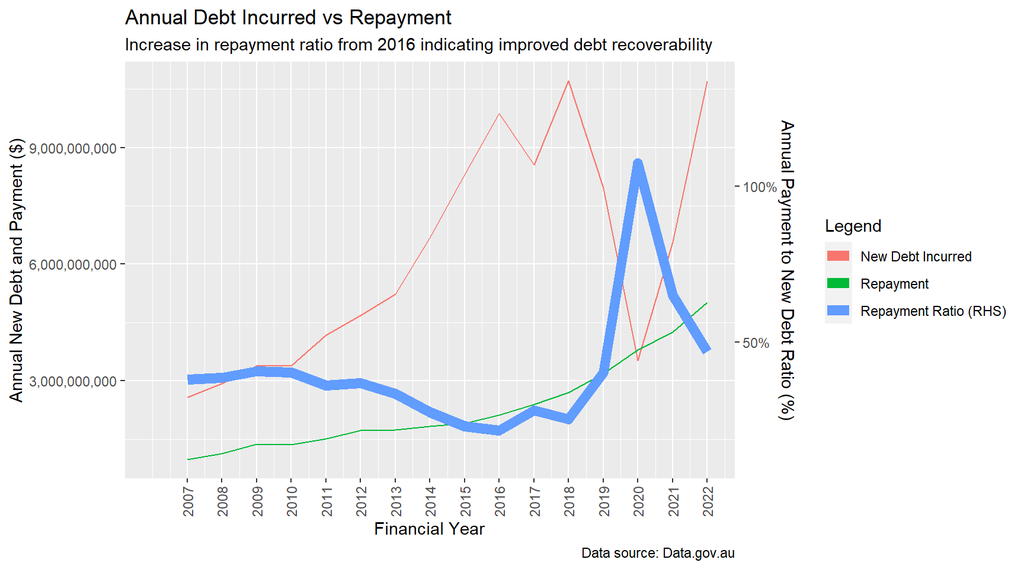

Figure 2.6: Annual New Debt Incurred and Repayments

Graph 2.6 shows significant increase in new debts under the program each year, start at below $3 billion in FY07 and increasing to over $10 billion per year in FY18 and FY22. Annual increase in repayments have occurred at a slower rate, but follows an exponential trajectory to FY22. Repayment to new debt ratio have been calculated as primary indicator for recoverability of debt issued under the scheme. Between FY07 to FY16, this indicators shows a concerning trend as it decreased from 38% to 21% as new debt outpaced repayments. However this have recovered substantially in recent years (reaching >100% in FY20 which is an outlier due to low new debt in the year) which means that even as greater amounts are lent under this program year on year, it still appears to be a sustainable one as annual repayments received have grown steadily over the past 6 years.

### 2.3.2 Debt Write Off Ratio

Table 2.7: Debt Writeoff as % of Annual New Debt

| Financial Year | Debt Writeoff Ratio |
| --- | --- |
| 2007 | 0.0019841 |
| 2008 | 0.0018709 |
| 2009 | 0.0020545 |
| 2010 | 0.0012205 |
| 2011 | -0.0001352 |
| 2012 | 0.0000000 |
| 2013 | 0.0039650 |
| 2014 | 0.0006611 |
| 2015 | 0.0014128 |
| 2016 | 0.0000082 |
| 2017 | 0.0000155 |
| 2018 | 0.0006161 |
| 2019 | 0.0046025 |
| 2020 | 0.0059912 |
| 2021 | 0.0011915 |
| 2022 | 0.0055992 |

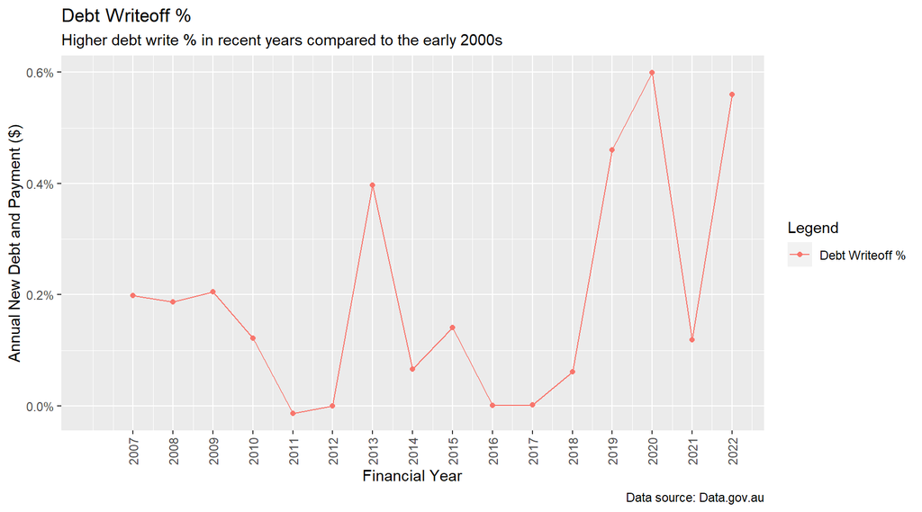

Figure 2.7: Debt Writeoff as % of Annual New Debt

In table 2.7 Annual debt writeoff as percentage of new debts is similar to the measure of loss rate measured for major banks. For the year 2019, average loss rate across the 3 major banks (ANZ, CBA, NAB) averages 0.15% (Dunn et al., 2019). The calculated HELP debt writeoff % for FY is 0.46%, while substantially higher than the private banks, the HELP debt writeoff % is not unreasonable given the difference in nature compared to a commercial loan.

# 3 Conclusion

The number of debtors and outstanding debt has steadily increased since 2005. From 2005 to 2021, there has been an increase of 1.82 million people in debt. During this same period, there has been an increase in outstanding debt of $62 billion 2.1.1. Females are more likely to have HELP debt and there is an increasing gap between males and females in debt 2.1.2. It appears with age, the risk of student debt decreases. All age groups increased in debtors and outstanding debt for 2005-2021, except for the age group 0-19, which saw a sudden drop in 2018-2021 2.1.3. Overall, Student debt levels are rising, along with a rise in older people with outstanding debt, especially women (Preston, 2023).

Based on the analysis in 2.2.1 and 2.2.2, most debtors earn below the average income, while the number of debtors earning above the average diminishes as the income group increases. The skewed distribution in Figure 2.4 represents the government’s risk in recovering HELP debt in 2021. Up to $20,000 to $29,999, the risk increases as many debtors fail to meet the minimum repayment threshold. However, beyond $30,000, income increases correlate with decreasing risk as more repayments are made through the tax system.

However, this analysis is limited by the data not accounting for the size of HELP debt incurred and how progressed the debtor is in their career. Further progressed careers and larger debts from higher education may correlate with an increase in the level of income earned, and vice versa. The increase of median and mean income observed in Figure 2.5 indicate an overall inflation of debtor income since 2009, suggesting an improved ability to repay HELP debt and indicating good long-term sustainability for the program. This observation is supported by Figure 2.6 which shows significant increase in annual payments received from 2016 reflective of increased debtor income and being pushed into higher repayment brackets.

# 4 References

Albrecht, D., & Ziderman, A. (1991). *Deferred cost recovery for higher education: Student loan programs in developing countries*. World Bank. https://books.google.com.au/books?id=GCWa2sbFoD0C

Altmann, B., Hornik, K., Kalibera, T., Ligges, U., Ripley, B. D., Urbanek, S., & Wimmer, V. (2023). *The comprehensive r archive network* (Version 4.3.0). https://cran.rstudio.com/

Australian Taxation Office. (2022). *Higher education loan program (HELP)*. Australian Taxation Office. https://data.gov.au/data/dataset/higher-education-loan-program-help

Baum, S. (2016). Student loan programs and the realities of student debt. In *Student debt* (pp. 17–42). Palgrave Macmillan.

Callender, C., & Mason, G. (2017). Does student loan debt deter higher education participation? New evidence from england. *Sage Journals*, *671*(1). https://journals.sagepub.com/doi/abs/10.1177/0002716217696041

Dunn, W., Kamath, R., Mucherla, R., Pereira, I., Perera, S., & Rogers, J. (2019). *The reality of a new era for australian banking, banking matters, major banks analysis full year november 2019* (Banking Matters, Major Banks Analysis Full Year November 2019). PwC. https://www.pwc.com.au/banking-capital-markets/banking-matters/mba_banking_matters_nov_full_19.pdf

Jackson, K., Esguerra, E., Callaway, N., Liao, J., & Morris, A. (2016). *Administration of higher education loan program debt and repayments* (Technical Report, Vol. 31). Australian National Audit Office.

OECD. (2018). *Benefits of educational attainment*. Australian Government, Department of Education.

Posit. (2023). *RStudio IDE* (Version 2023.06.0+421). https://posit.co/products/open-source/rstudio/

Preston, A. (2023). *Gender and australia’s higher education loan program. The university of western australia* [Submission to the Review of Australia’s Higher Education System]. Department of Economics UWA Business School. https://www.education.gov.au/system/files/documents/submission-file/2023-04/AUA_tranche2_Alison%20Preston.pdf

Universities Australia. (2022). *2022 higher education facts and figures*. Universities Australia. https://www.universitiesaustralia.edu.au/wp-content/uploads/2022/09/220207-HE-Facts-and-Figures-2022_2.0.pdf